# Trabalho Prático - Extração de Conhecimento de Dados Biológicos

Diogo Barreira, Gonçalo Gomes, José Campos

2026-04-21

# 1. Introdução

Os dados utilizados para o desenvolvimento do trabalho prático são provenientes do “The Cancer Genome Atlas” (TCGA), mais concretamente referentes ao carcinoma da tiróide (THCA) e foram consultados através do portal do National Cancer Institute. A escolha desta base de dados justifica-se pelo cancro da tiróide ser uma neoplasia endócrina muito comum (Wang et al., 2017; Du et al., 2021). Os autores acrescentam ainda que apesar de tipicamente os prognósticos serem bons, uma parte dos casos apresenta um comportamento muito agressivo. O TCGA-THCA permitiu que fossem identificados subtipos moleculares importantes, tais como perfis BRAF-like e RAS-like essenciais para a medicina de precisão (The Cancer Genome Atlas Research Network, 2014).

# 2. Os Dados

Os dados utilizados foram obtidos através do pacote TCGAbiolinks, que permite aceder diretamente ao repositório Genomic Data Commons (GDC).

- **Projeto:** TCGA-THCA
- **Tipo de dados:** expressão génica (RNA-Seq)
- **Formato:** contagens de leitura por gene

Estes dados são relevantes porque permitem comparar a expressão génica entre tumores e tecidos normais, possibilitando a identificação de genes associados ao desenvolvimento do cancro.

# 3. Carregamento e preparação dos dados

```r
if (!require("BiocManager", quietly = TRUE))
    install.packages("BiocManager")
BiocManager::install(version = "3.22", ask = FALSE, update = FALSE)
BiocManager::install(c("GenomicFeatures", "AnnotationDbi"), ask = FALSE, update = FALSE)
BiocManager::install("TCGAbiolinks", ask = FALSE, update = FALSE)
library(BiocManager)
library(TCGAbiolinks)
library(SummarizedExperiment)
```

```r
query_thca <- GDCquery(
    project       = "TCGA-THCA",
    data.category = "Transcriptome Profiling",
    data.type     = "Gene Expression Quantification",
    workflow.type = "STAR - Counts"
)
```

```
## o GDCquery: Searching in GDC database
```

```
## Genome of reference: hg38
```

```
## oo Accessing GDC. This might take a while...
```

```
## ooo Project: TCGA-THCA
```

```
## oo Filtering results
```

```
## ooo By data.type
```

```
## ooo By workflow.type
```

```
## oo Checking data
```

```
## ooo Checking if there are duplicated cases
```

```
## ooo Checking if there are results for the query
```

```
## o Preparing output
```

```r
GDCdownload(query_thca)
```

```
## Of the 572 files for download 572 already exist.
```

```
## All samples have been already downloaded
```

```r
data_thca <- GDCprepare(query_thca)
```

```
## Starting to add information to samples
```

```
##  => Add clinical information to samples
```

```
##  => Adding TCGA molecular information from marker papers
```

```
##  => Information will have prefix 'paper_'
```

```
## thca subtype information from:doi:10.1016/j.cell.2014.09.050
```

```
## Available assays in SummarizedExperiment :
##   => unstranded
##   => stranded_first
##   => stranded_second
##   => tpm_unstrand
##   => fpkm_unstrand
##   => fpkm_uq_unstrand
```

```r
# Descarregamento e preparação dos dados de expressão génica.
```

```r
exp_matrix <- assay(data_thca)
# Matriz de expressão: linhas = genes, colunas = amostras.
```

## 3.1 Dimensões do dataset

```r
cat("Dimensões antes da filtragem:", dim(exp_matrix), "\n")
```

```
## Dimensões antes da filtragem: 60660 572
```

# 4. Pré-processamento dos dados

## 4.1 Filtragem de genes pouco expressos

```r
keep         <- rowSums(exp_matrix > 10) >= 10
exp_filtered <- exp_matrix[keep, ]
# Remoção dos genes de baixa expressão.
```

## 4.2 Dimensões após filtragem

```r
cat("Dimensões após filtragem:", dim(exp_filtered), "\n")
```

```
## Dimensões após filtragem: 28300 572
```

## 4.3 Transformação logarítmica

```r
exp_log <- log2(exp_filtered + 1)
# Transformação log2 para estabilizar a variância e tornar os dados
# mais adequados para análise estatística.
```

# 5. Análise exploratória e estatística descritiva

## 5.1 Estatísticas básicas

```r
summary(exp_log[, 1:5])
```

```
##  TCGA-DJ-A2Q6-01A-11R-A18C-07 TCGA-FK-A3SE-01A-11R-A22L-07
##  Min.   : 0.000               Min.   : 0.000
##  1st Qu.: 3.700               1st Qu.: 3.322
##  Median : 7.229               Median : 6.931
##  Mean   : 7.376               Mean   : 7.120
##  3rd Qu.:11.163               3rd Qu.:10.965
##  Max.   :21.023               Max.   :21.036
##  TCGA-DJ-A2QA-01A-11R-A18C-07 TCGA-FY-A2QD-01A-11R-A19O-07
##  Min.   : 0.000               Min.   : 0.000
##  1st Qu.: 2.000               1st Qu.: 2.585
##  Median : 5.644               Median : 6.109
##  Mean   : 5.779               Mean   : 6.443
##  3rd Qu.: 9.484               3rd Qu.:10.424
##  Max.   :21.245               Max.   :22.013
##  TCGA-EL-A3GR-01A-21R-A206-07
##  Min.   : 0.000
##  1st Qu.: 3.170
##  Median : 6.524
##  Mean   : 6.743
##  3rd Qu.:10.396
##  Max.   :19.919
```

```r
# Mínimos, máximos, média e quartis das primeiras 5 amostras.
```

## 5.2 Visualização da distribuição

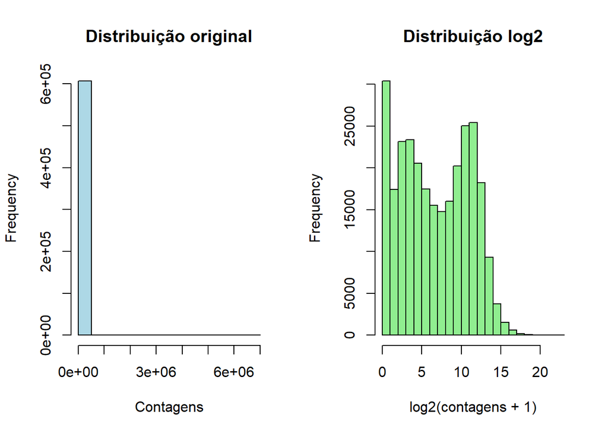

```r
par(mfrow = c(1, 2))
hist(as.numeric(exp_matrix[, 1:10]),
     main = "Distribuição original", col = "lightblue",  xlab = "Contagens")
hist(as.numeric(exp_log[, 1:10]),
     main = "Distribuição log2",     col = "lightgreen", xlab = "log2(contagens + 1)")
```

```r
par(mfrow = c(1, 1))
# A logaritmização reduz a assimetria da distribuição.
```

## 5.3 Boxplot das amostras

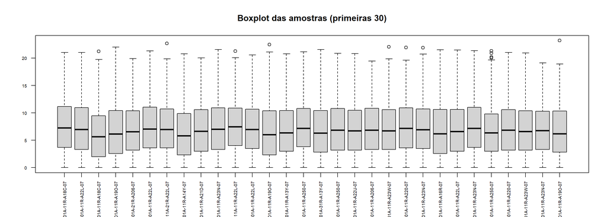

```r
boxplot(exp_log[, 1:30],
        main     = "Boxplot das amostras (primeiras 30)",
        las      = 2,
        cex.axis = 0.6)
```

```r
# Permite identificar diferenças entre amostras e possíveis outliers.
```

## 5.4 Heatmap dos genes mais variáveis

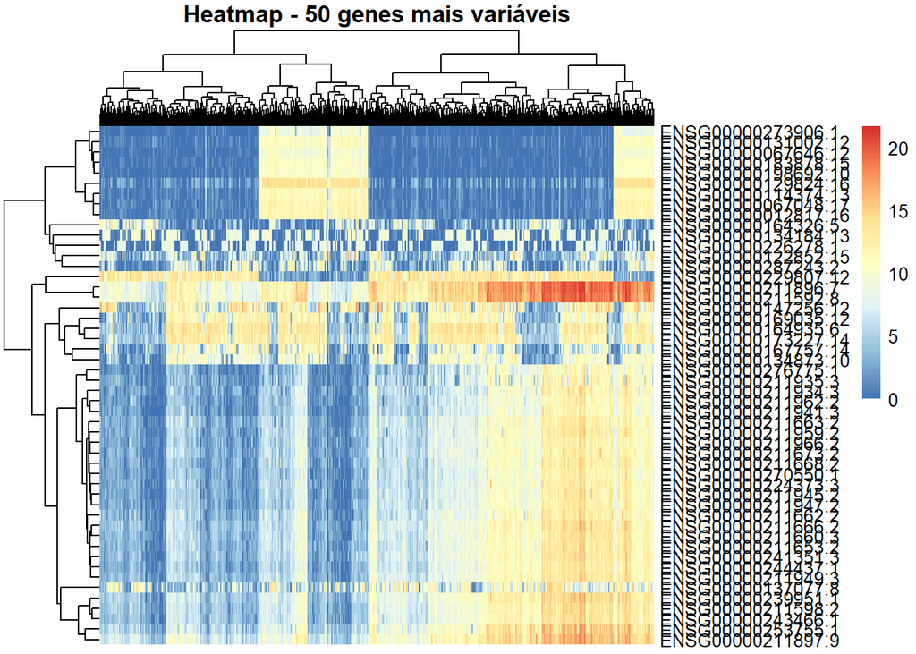

```r
library(pheatmap)
var_genes     <- apply(exp_log, 1, var)
top_var_genes <- names(sort(var_genes, decreasing = TRUE))[1:50]

pheatmap(exp_log[top_var_genes, ],
         show_colnames = FALSE,
         main          = "Heatmap - 50 genes mais variáveis")
```

# 6. Definição dos grupos

```r
group <- ifelse(substr(colnames(exp_log), 14, 15) == "01", "Tumor", "Normal")
table(group)
```

```
## group
## Normal  Tumor
##     67    505
```

As amostras são classificadas como **Tumor** ou **Normal** com base nas posições 14-15 do barcode TCGA.

## 6.1 PCA das amostras

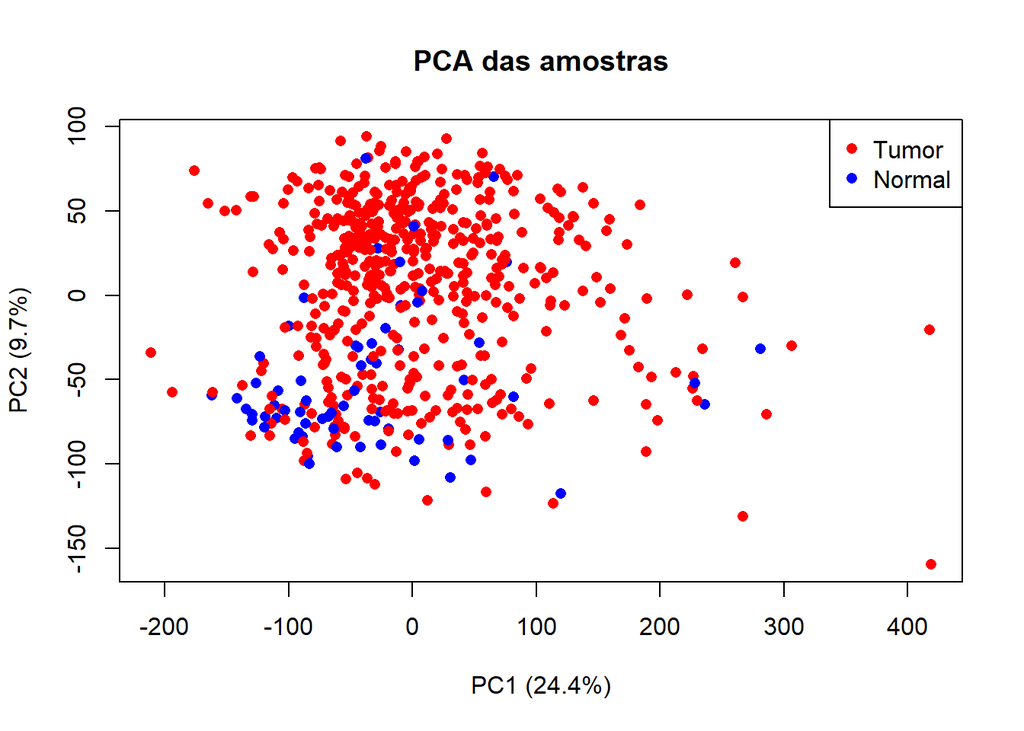

```r
pca <- prcomp(t(exp_log), scale. = TRUE)

plot(pca$x[, 1], pca$x[, 2],
     col  = ifelse(group == "Tumor", "red", "blue"),
     pch  = 16,
     xlab = paste0("PC1 (", round(summary(pca)$importance[2, 1] * 100, 1), "%)"),
     ylab = paste0("PC2 (", round(summary(pca)$importance[2, 2] * 100, 1), "%)"),
     main = "PCA das amostras")
legend("topright", legend = c("Tumor", "Normal"), col = c("red", "blue"), pch = 16)
```

# 7. Análise de expressão diferencial

```r
p_values <- apply(exp_log, 1, function(gene) {
  t.test(gene ~ group)$p.value
})
# Teste t para cada gene para comparar os dois grupos.

p_adj     <- p.adjust(p_values, method = "fdr")
diff_genes <- which(p_adj < 0.05)
# Correção FDR para controlar falsos positivos.
```

## 7.1 Contagem de DEGs

```r
cat("Genes diferencialmente expressos (FDR < 0.05):", length(diff_genes), "\n")
```

```
## Genes diferencialmente expressos (FDR < 0.05): 18572
```

## 7.2 Volcano plot

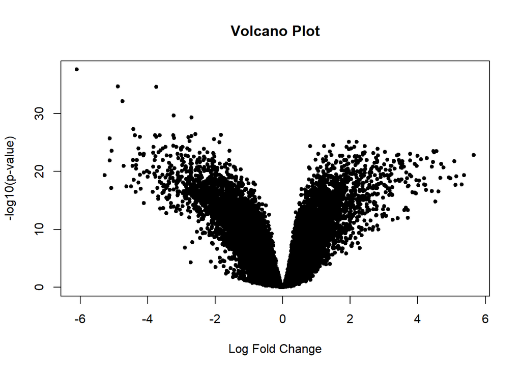

```r
logFC <- rowMeans(exp_log[, group == "Tumor"]) -
         rowMeans(exp_log[, group == "Normal"])

plot(logFC, -log10(p_adj),
     pch  = 20,
     main = "Volcano Plot",
     xlab = "Log Fold Change",
     ylab = "-log10(p-value)")
```

```r
# Visualização dos genes significativamente alterados.
```

## 7.3 Tabela top DEGs

```r
top_degs <- data.frame(
  logFC = logFC[diff_genes],
  p_adj = p_adj[diff_genes]
)
head(top_degs[order(top_degs$p_adj), ], 20)
```

```
##                        logFC        p_adj
## ENSG00000137077.8  -6.104609 2.735625e-38
## ENSG00000143196.5  -4.890773 2.257070e-35
## ENSG00000039537.14 -3.751651 2.520640e-35
## ENSG00000196616.14 -4.750055 8.381511e-33
## ENSG00000130595.19 -3.234983 2.456111e-30
## ENSG00000231246.2  -2.699262 5.221089e-30
## ENSG00000101938.15 -4.425668 4.859036e-28
## ENSG00000126218.12 -2.593505 3.881213e-27
## ENSG00000063127.16 -1.830417 5.517752e-27
## ENSG00000147257.15 -3.781958 5.599652e-27
## ENSG00000151892.15 -3.238047 6.232971e-27
## ENSG00000179915.24 -3.640694 6.249644e-27
## ENSG00000205221.12 -4.383244 6.249644e-27
## ENSG00000230587.2  -2.701673 8.309230e-27
## ENSG00000070193.5  -4.233078 1.152366e-26
## ENSG00000138356.14 -3.745662 1.152366e-26
## ENSG00000111339.12 -2.798475 1.376473e-26
## ENSG00000127241.18 -3.224377 1.744490e-26
## ENSG00000168079.17 -5.128585 1.938720e-26
## ENSG00000180828.3  -2.037712 2.774685e-26
```

# 8. Análise de enriquecimento funcional

```r
genes       <- rownames(exp_log)[diff_genes]
genes_clean <- sub("\\..*", "", genes)
head(genes_clean)
```

```
## [1] "ENSG00000000005" "ENSG00000000419" "ENSG00000000457" "ENSG00000000971"
## [5] "ENSG00000001036" "ENSG00000001084"
```

```r
# Limpeza dos IDs ENSEMBL (remoção de sufixos de versão).
```

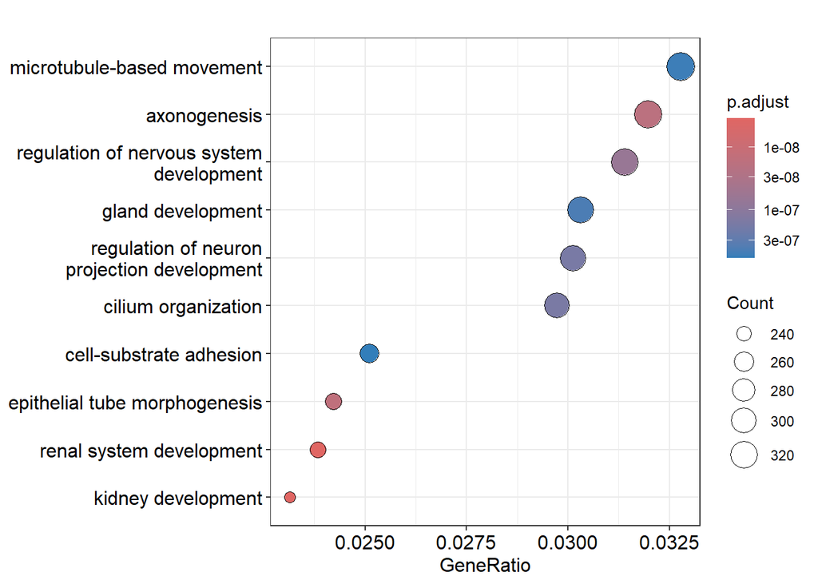

```r
library(clusterProfiler)
library(org.Hs.eg.db)

entrez_ids <- bitr(
  genes_clean,
  fromType = "ENSEMBL",
  toType   = "ENTREZID",
  OrgDb    = org.Hs.eg.db
)

ego <- enrichGO(
  gene          = entrez_ids$ENTREZID,
  OrgDb         = org.Hs.eg.db,
  ont           = "BP",
  pAdjustMethod = "BH",
  pvalueCutoff  = 0.05
)

dotplot(ego, showCategory = 10)
```

```r
# Processos biológicos enriquecidos nos genes diferencialmente expressos.
```

Foi necessário converter os identificadores ENSEMBL para ENTREZID e remover sufixos de versão, uma vez que ferramentas de enriquecimento funcional requerem formatos específicos de identificação génica. Aproximadamente 24.76% dos genes não foram convertidos para ENTREZ ID, resultado esperado devido a limitações nas bases de dados e diferenças na anotação génica.

# 9. Guardar dados para a Fase 2

```r
# IMPORTANTE: guarda o objeto SummarizedExperiment para ser carregado na fase 2.
# O ficheiro será criado na mesma pasta deste .Rmd.
saveRDS(data_thca, file = "dados_thca.rds")
cat("Ficheiro 'dados_thca.rds' guardado com sucesso.\n")
```

```
## Ficheiro 'dados_thca.rds' guardado com sucesso.
```